# Control 2 de Prácticas

Francisco Javier Mercader Martínez

# Problema 1

```r
d <- read.csv("data/wine_A.csv", header = TRUE, sep = ";", dec = ",")

# Nos podremos planterar un análisis de componentes principales si las variables presentan correlación.

str(d)
```

```
## 'data.frame':    178 obs. of  14 variables:
##  $ wine_class                  : int  1 1 1 1 1 1 1 1 1 1 ...
##  $ Alcohol                     : num  14.2 13.2 13.2 14.4 13.2 ...
##  $ Malic.acid                  : num  1.71 1.78 2.36 1.95 2.59 1.76 1.87 2.15 1.64 1.35 ...
##  $ Ash                         : num  2.43 2.14 2.67 2.5 2.87 2.45 2.45 2.61 2.17 2.27 ...
##  $ Alcalinity.of.ash           : num  15.6 11.2 18.6 16.8 21 15.2 14.6 17.6 14 16 ...
##  $ Magnesium                   : int  127 100 101 113 118 112 96 121 97 98 ...
##  $ Total.phenols               : num  2.8 2.65 2.8 3.85 2.8 3.27 2.5 2.6 2.8 2.98 ...
##  $ Flavanoids                  : num  3.06 2.76 3.24 3.49 2.69 3.39 2.52 2.51 2.98 3.15 ...
##  $ Nonflavanoid.phenols        : num  0.28 0.26 0.3 0.24 0.39 0.34 0.3 0.31 0.29 0.22 ...
##  $ Proanthocyanins             : num  2.29 1.28 2.81 2.18 1.82 1.97 1.98 1.25 1.98 1.85 ...
##  $ Color.intensity             : num  5.64 4.38 5.68 7.8 4.32 6.75 5.25 5.05 5.2 7.22 ...
##  $ Hue                         : num  1.04 1.05 1.03 0.86 1.04 1.05 1.02 1.06 1.08 1.01 ...
##  $ OD280.OD315.of.diluted.wines: num  3.92 3.4 3.17 3.45 2.93 2.85 3.58 3.58 2.85 3.55 ...
##  $ Proline                     : int  1065 1050 1185 1480 735 1450 1290 1295 1045 1045 ...
```

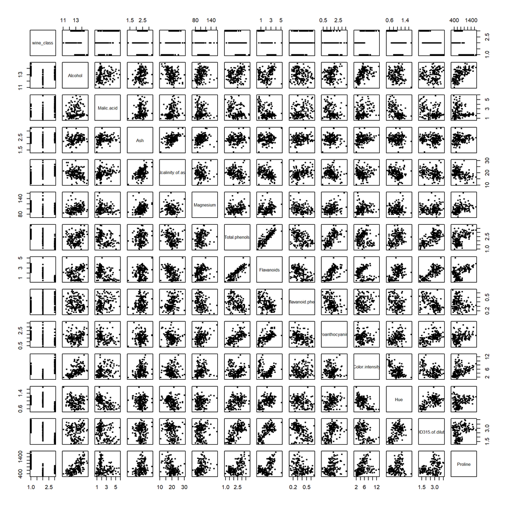

```r
plot(d, pch=20, cex=0.8)
```

```r
cov(d)
```

```
##                                 wine_class      Alcohol   Malic.acid
## wine_class                      0.60067924  -0.20651527   0.37903860
## Alcohol                        -0.20651527   0.65906233   0.08561131
## Malic.acid                      0.37903860   0.08561131   1.24801540
## Ash                            -0.01055545   0.04711516   0.05027704
## Alcalinity.of.ash               1.34036374  -0.84109290   1.07633171
## Magnesium                      -2.31549546   3.13987812  -0.87077953
## Total.phenols                  -0.34883483   0.14688722  -0.23433772
## Flavanoids                     -0.65609059   0.19203322  -0.45863037
## Nonflavanoid.phenols            0.04717736  -0.01575426   0.04073336
## Proanthocyanins                -0.22141306   0.06351752  -0.14114698
## Color.intensity                 0.47733891   1.02828254   0.64483818
## Hue                            -0.10936755  -0.01331344  -0.14332564
## OD280.OD315.of.diluted.wines   -0.43373707   0.04169782  -0.29244748
## Proline                      -154.66765061 164.56718498 -67.54886657
##                                        Ash Alcalinity.of.ash    Magnesium
## wine_class                   -0.0105554498         1.3403637   -2.3154955
## Alcohol                       0.0471151590        -0.8410929    3.1398781
## Malic.acid                    0.0502770393         1.0763317   -0.8707795
## Ash                           0.0752646353         0.4062083    1.1229366
## Alcalinity.of.ash             0.4062082778        11.1526862   -3.9747604
## Magnesium                     1.1229365835        -3.9747604  203.9893354
## Total.phenols                 0.0221455913        -0.6711491    1.9164699
## Flavanoids                    0.0315347299        -1.1720828    2.7930870
## Nonflavanoid.phenols          0.0063584714         0.1504219   -0.4555634
## Proanthocyanins               0.0015155780        -0.3771762    1.9328325
## Color.intensity               0.1646543266         0.1450242    6.6205206
## Hue                          -0.0046821545        -0.2091181    0.1808513
## OD280.OD315.of.diluted.wines  0.0007618358        -0.6562344    0.6693081
## Proline                      19.3197390973      -463.3553450 1769.1586999
##                              Total.phenols   Flavanoids Nonflavanoid.phenols
## wine_class                     -0.34883483  -0.65609059          0.047177363
## Alcohol                         0.14688722   0.19203322         -0.015754260
## Malic.acid                     -0.23433772  -0.45863037          0.040733362
## Ash                             0.02214559   0.03153473          0.006358471
## Alcalinity.of.ash              -0.67114915  -1.17208281          0.150421856
## Magnesium                       1.91646988   2.79308703         -0.455563385
## Total.phenols                   0.39168954   0.54047042         -0.035045125
## Flavanoids                      0.54047042   0.99771867         -0.066867000
## Nonflavanoid.phenols           -0.03504512  -0.06686700          0.015488634
```

[output cut: 20 more lines]

```
##                              OD280.OD315.of.diluted.wines     Proline
## wine_class                                  -0.4337370660  -154.66765
## Alcohol                                      0.0416978226   164.56718
## Malic.acid                                  -0.2924474830   -67.54887
## Ash                                          0.0007618358    19.31974
## Alcalinity.of.ash                           -0.6562343681  -463.35535
## Magnesium                                    0.6693080683  1769.15870
## Total.phenols                                0.3110212785    98.17106
## Flavanoids                                   0.5582622548   155.44749
## Nonflavanoid.phenols                        -0.0444692440   -12.20359
## Proanthocyanins                              0.2109329398    59.55433
## Color.intensity                             -0.7058125762   230.76748
## Hue                                          0.0917662439    17.00022
## OD280.OD315.of.diluted.wines                 0.5040864089    69.92753
## Proline                                     69.9275255507 99166.71736
```

```r
cor(d)
```

```
##                               wine_class     Alcohol  Malic.acid          Ash
## wine_class                    1.00000000 -0.32822194  0.43777620 -0.049643221
## Alcohol                      -0.32822194  1.00000000  0.09439694  0.211544596
## Malic.acid                    0.43777620  0.09439694  1.00000000  0.164045470
## Ash                          -0.04964322  0.21154460  0.16404547  1.000000000
## Alcalinity.of.ash             0.51785911 -0.31023514  0.28850040  0.443367187
## Magnesium                    -0.20917939  0.27079823 -0.05457510  0.286586691
## Total.phenols                -0.71916334  0.28910112 -0.33516700  0.128979538
## Flavanoids                   -0.84749754  0.23681493 -0.41100659  0.115077279
## Nonflavanoid.phenols          0.48910916 -0.15592947  0.29297713  0.186230446
## Proanthocyanins              -0.49912982  0.13669791 -0.22074619  0.009651935
## Color.intensity               0.26566757  0.54636420  0.24898534  0.258887259
## Hue                          -0.61736921 -0.07174720 -0.56129569 -0.074666889
## OD280.OD315.of.diluted.wines -0.78822959  0.07234319 -0.36871043  0.003911231
## Proline                      -0.63371678  0.64372004 -0.19201056  0.223626264
##                              Alcalinity.of.ash   Magnesium Total.phenols
## wine_class                          0.51785911 -0.20917939   -0.71916334
## Alcohol                            -0.31023514  0.27079823    0.28910112
## Malic.acid                          0.28850040 -0.05457510   -0.33516700
## Ash                                 0.44336719  0.28658669    0.12897954
## Alcalinity.of.ash                   1.00000000 -0.08333309   -0.32111332
## Magnesium                          -0.08333309  1.00000000    0.21440123
## Total.phenols                      -0.32111332  0.21440123    1.00000000
## Flavanoids                         -0.35136986  0.19578377    0.86456350
## Nonflavanoid.phenols                0.36192172 -0.25629405   -0.44993530
## Proanthocyanins                    -0.19732684  0.23644061    0.61241308
## Color.intensity                     0.01873198  0.19995001   -0.05513642
## Hue                                -0.27395522  0.05539820    0.43368134
## OD280.OD315.of.diluted.wines       -0.27676855  0.06600394    0.69994936
## Proline                            -0.44059693  0.39335085    0.49811488
##                              Flavanoids Nonflavanoid.phenols Proanthocyanins
## wine_class                   -0.8474975            0.4891092    -0.499129824
## Alcohol                       0.2368149           -0.1559295     0.136697912
## Malic.acid                   -0.4110066            0.2929771    -0.220746187
## Ash                           0.1150773            0.1862304     0.009651935
## Alcalinity.of.ash            -0.3513699            0.3619217    -0.197326836
## Magnesium                     0.1957838           -0.2562940     0.236440610
## Total.phenols                 0.8645635           -0.4499353     0.612413084
## Flavanoids                    1.0000000           -0.5378996     0.652691769
## Nonflavanoid.phenols         -0.5378996            1.0000000    -0.365845099
```

[output cut: 20 more lines]

```
##                              OD280.OD315.of.diluted.wines    Proline
## wine_class                                   -0.788229589 -0.6337168
## Alcohol                                       0.072343187  0.6437200
## Malic.acid                                   -0.368710428 -0.1920106
## Ash                                           0.003911231  0.2236263
## Alcalinity.of.ash                            -0.276768549 -0.4405969
## Magnesium                                     0.066003936  0.3933508
## Total.phenols                                 0.699949365  0.4981149
## Flavanoids                                    0.787193902  0.4941931
## Nonflavanoid.phenols                         -0.503269596 -0.3113852
## Proanthocyanins                               0.519067096  0.3304167
## Color.intensity                              -0.428814942  0.3161001
## Hue                                           0.565468293  0.2361834
## OD280.OD315.of.diluted.wines                  1.000000000  0.3127611
## Proline                                       0.312761075  1.0000000
```

Considero que la matriz de correlaciones es más apropiada ya que es mejor utilizar los datos tipificados.

Para saber si las correlaciones anteriores son significativas, podemos usar la función *rcorr()* del paquete *Hmisc*, para obtener tanto el valor de las correlaciones como el p-valor del contraste de significación de cada correlación.

```r
library("Hmisc")
rcorr(as.matrix(d))
```

```
##                              wine_class Alcohol Malic.acid   Ash
## wine_class                         1.00   -0.33       0.44 -0.05
## Alcohol                           -0.33    1.00       0.09  0.21
## Malic.acid                         0.44    0.09       1.00  0.16
## Ash                               -0.05    0.21       0.16  1.00
## Alcalinity.of.ash                  0.52   -0.31       0.29  0.44
## Magnesium                         -0.21    0.27      -0.05  0.29
## Total.phenols                     -0.72    0.29      -0.34  0.13
## Flavanoids                        -0.85    0.24      -0.41  0.12
## Nonflavanoid.phenols               0.49   -0.16       0.29  0.19
## Proanthocyanins                   -0.50    0.14      -0.22  0.01
## Color.intensity                    0.27    0.55       0.25  0.26
## Hue                               -0.62   -0.07      -0.56 -0.07
## OD280.OD315.of.diluted.wines      -0.79    0.07      -0.37  0.00
## Proline                           -0.63    0.64      -0.19  0.22
##                              Alcalinity.of.ash Magnesium Total.phenols
## wine_class                                0.52     -0.21         -0.72
## Alcohol                                  -0.31      0.27          0.29
## Malic.acid                                0.29     -0.05         -0.34
## Ash                                       0.44      0.29          0.13
## Alcalinity.of.ash                         1.00     -0.08         -0.32
## Magnesium                                -0.08      1.00          0.21
## Total.phenols                            -0.32      0.21          1.00
## Flavanoids                               -0.35      0.20          0.86
## Nonflavanoid.phenols                      0.36     -0.26         -0.45
## Proanthocyanins                          -0.20      0.24          0.61
## Color.intensity                           0.02      0.20         -0.06
## Hue                                      -0.27      0.06          0.43
## OD280.OD315.of.diluted.wines             -0.28      0.07          0.70
## Proline                                  -0.44      0.39          0.50
##                              Flavanoids Nonflavanoid.phenols Proanthocyanins
## wine_class                        -0.85                 0.49           -0.50
## Alcohol                            0.24                -0.16            0.14
## Malic.acid                        -0.41                 0.29           -0.22
## Ash                                0.12                 0.19            0.01
## Alcalinity.of.ash                 -0.35                 0.36           -0.20
## Magnesium                          0.20                -0.26            0.24
## Total.phenols                      0.86                -0.45            0.61
## Flavanoids                         1.00                -0.54            0.65
## Nonflavanoid.phenols              -0.54                 1.00           -0.37
```

[output cut: 100 more lines]

```
##                              OD280.OD315.of.diluted.wines Proline
## wine_class                   0.0000                       0.0000
## Alcohol                      0.3372                       0.0000
## Malic.acid                   0.0000                       0.0102
## Ash                          0.9587                       0.0027
## Alcalinity.of.ash            0.0002                       0.0000
## Magnesium                    0.3814                       0.0000
## Total.phenols                0.0000                       0.0000
## Flavanoids                   0.0000                       0.0000
## Nonflavanoid.phenols         0.0000                       0.0000
## Proanthocyanins              0.0000                       0.0000
## Color.intensity              0.0000                       0.0000
## Hue                          0.0000                       0.0015
## OD280.OD315.of.diluted.wines                              0.0000
## Proline                      0.0000
```

Observamos varios p-valores inferiores a 0.05, lo que indica que las correspondiente correlaciones son significativas, por lo tanto existe correlación entre algunas variables.

```r
PCA <- princomp(d, cor = TRUE)
summary(PCA)
```

```
## Importance of components:
##                           Comp.1    Comp.2    Comp.3     Comp.4     Comp.5
## Standard deviation     2.3528595 1.5802140 1.2025283 0.96328492 0.93675104
## Proportion of Variance 0.3954249 0.1783626 0.1032910 0.06627984 0.06267875
## Cumulative Proportion  0.3954249 0.5737874 0.6770785 0.74335831 0.80603706
##                           Comp.6     Comp.7     Comp.8     Comp.9    Comp.10
## Standard deviation     0.8202307 0.74417670 0.59163686 0.54271718 0.51215828
## Proportion of Variance 0.0480556 0.03955707 0.02500244 0.02103871 0.01873615
## Cumulative Proportion  0.8540927 0.89364973 0.91865217 0.93969088 0.95842703
##                           Comp.11    Comp.12     Comp.13     Comp.14
## Standard deviation     0.47523512 0.41084877 0.359950245 0.240441928
## Proportion of Variance 0.01613203 0.01205691 0.009254584 0.004129451
## Cumulative Proportion  0.97455906 0.98661596 0.995870549 1.000000000
```

```r
S <- PCA$scores
which.max(S[, 1])
```

```
## [1] 147
```

```r
which.min(S[, 1])
```

```
## [1] 15
```

```r
SAT <- cor(d, S)

mejor_variable <- apply(SAT, 2, function(x) which.max(abs(x)))

peor_variable <- apply(SAT, 2, function(x) which.min(abs(x)))

for (i in 1:3) {
  print(paste("Variable mejor representada por la componente", i, ":", colnames(d)[mejor_variable[i]]))
  print(paste("Variable peor representada por la componente", i, ":", colnames(d)[peor_variable[i]]))
}
```

```
## [1] "Variable mejor representada por la componente 1 : wine_class"
## [1] "Variable peor representada por la componente 1 : Ash"
## [1] "Variable mejor representada por la componente 2 : Color.intensity"
## [1] "Variable peor representada por la componente 2 : Flavanoids"
## [1] "Variable mejor representada por la componente 3 : Ash"
## [1] "Variable peor representada por la componente 3 : wine_class"
```

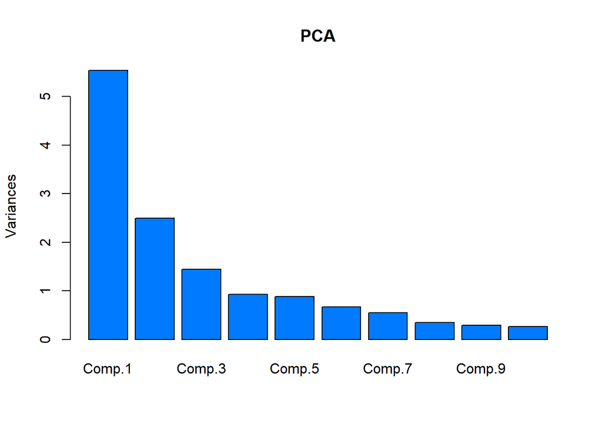

```r
# Grafo de sedimentación
screeplot(PCA, col="#007AFF")
```

Es posible que sea conveniente considerar sólo las 3 primeras variables ya que la proporción de variabilidad del resto es mucho menor

```r
COM3 = SAT[, 1]^2 + SAT[, 2]^2 + SAT[, 3]^2 # comunalidades si retenemos 3 componentes
COM3
```

```
##                   wine_class                      Alcohol
##                    0.8580204                    0.7504299
##                   Malic.acid                          Ash
##                    0.4107368                    0.8160160
##            Alcalinity.of.ash                    Magnesium
##                    0.8204494                    0.3363621
##                Total.phenols                   Flavanoids
##                    0.7568172                    0.8780537
##         Nonflavanoid.phenols              Proanthocyanins
##                    0.4382541                    0.4678446
##              Color.intensity                          Hue
##                    0.7722652                    0.6276083
## OD280.OD315.of.diluted.wines                      Proline
##                    0.7863032                    0.7599376
```

```r
print(paste("Variable mejor representada", colnames(d)[which.max(COM3)]))
```

```
## [1] "Variable mejor representada Flavanoids"
```

```r
print(paste("Variable peor representada:", colnames(d)[which.min(COM3)]))
```

```
## [1] "Variable peor representada: Magnesium"
```

```r
COM2 = SAT[, 1]^2 + SAT[, 2]^2
COM2
```

```
##                   wine_class                      Alcohol
##                    0.8580183                    0.6882269
##                   Malic.acid                          Ash
##                    0.3993348                    0.2491489
##            Alcalinity.of.ash                    Magnesium
##                    0.2788494                    0.3115519
##                Total.phenols                   Flavanoids
##                    0.7257779                    0.8450980
##         Nonflavanoid.phenols              Proanthocyanins
##                    0.3964746                    0.4353601
##              Color.intensity                          Hue
##                    0.7450182                    0.6170794
## OD280.OD315.of.diluted.wines                      Proline
##                    0.7463570                    0.7367287
```

# Problema 2

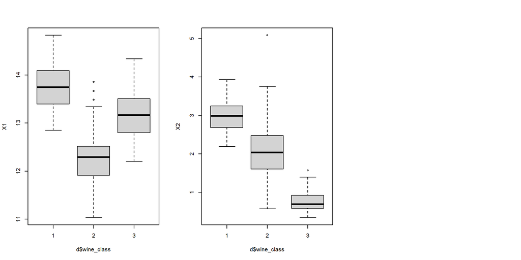

```r
X1 <- d$Alcohol
X2 <- d$Flavanoids
X3 <- d$Color.intensity

par(mfrow = c(1,3))
boxplot(X1 ~ d$wine_class)
boxplot(X2 ~ d$wine_class)
# boxplot(X3 ~ d$wine_class)
```

Para cada una de las variables se pude separar la `clase 2` de las otras porque no se solapan los gráficos de caja.

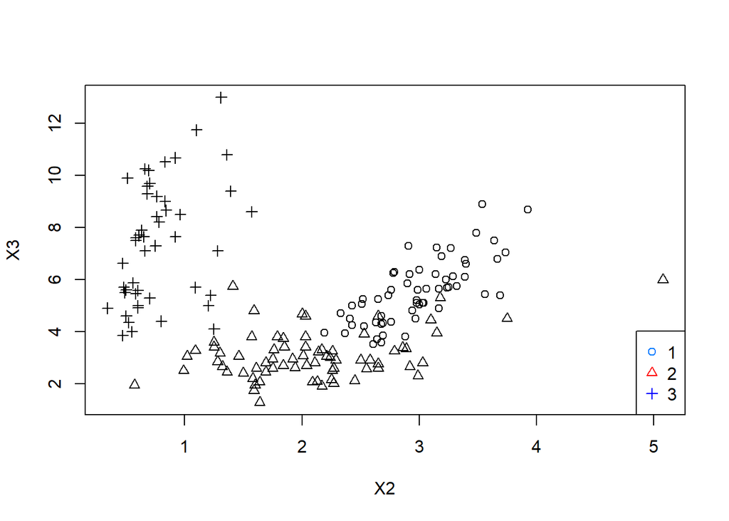

```r
plot(X2, X3, pch = as.integer(d$wine_class))
legend("bottomright", legend = unique(d$wine_class), pch = 1:3, col = c("#007AFF", "#FF0000", "#0000FF"))
```

```r
LDA <- lda(x = d[1:178, c("Alcohol", "Flavanoids", "Color.intensity")], grouping = d[1:178, 1], prior = c(1/3, 1/3, 1/3))
```

```r
LDA$scaling
```

```
##                        LD1       LD2
## Alcohol         -0.3892370 1.5653793
## Flavanoids      -1.8846764 0.2502131
## Color.intensity  0.5155774 0.2257060
```

```r
z = c(13, 1, 15)
predict(LDA, z)
```

```
## $class
## [1] 3
## Levels: 1 2 3
##
## $posterior
##                 1            2 3
## [1,] 9.716735e-15 9.846352e-14 1
##
## $x
##           LD1      LD2
## [1,] 6.792087 1.851249
```

Se clasificaría en la clase 3 y la clasificación sería muy fiable

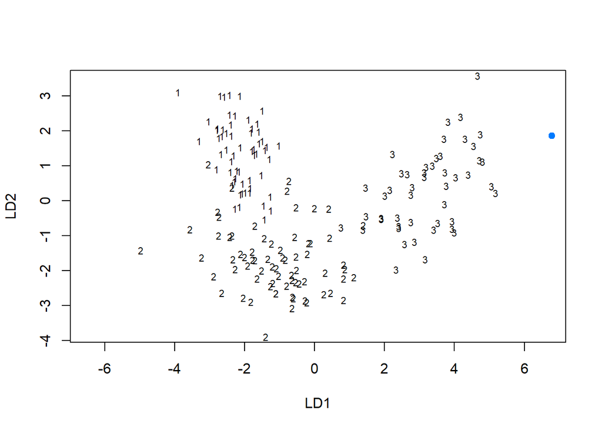

```r
plot(LDA)
points(predict(LDA, z)$x[1, 1], predict(LDA, z)$x[1,2], pch = 19, col = "#007AFF")
```

Se clasificaría en el grupo 3

```r
QDA <- qda(x = d[1:178, c("Alcohol", "Flavanoids", "Color.intensity")], grouping = d[1:178, 1], prior = c(1/3, 1/3, 1/3))
```

```r
z = c(13, 1, 15)
predict(QDA, z)
```

```
## $class
## [1] 3
## Levels: 1 2 3
##
## $posterior
##                 1            2 3
## [1,] 4.289176e-66 1.202743e-46 1
```

Se clasificaría en la clase 3 y la clasificación sería muy fiable

```r
LDACV <- lda(x = d[1:178, c("Alcohol", "Flavanoids", "Color.intensity")], grouping = d[1:178, 1], prior = c(1/3, 1/3, 1/3), CV=TRUE)
QDACV <- qda(x = d[1:178, c("Alcohol", "Flavanoids", "Color.intensity")], grouping = d[1:178, 1], prior = c(1/3, 1/3, 1/3), CV=TRUE)

table(LDACV$class, d$wine_class)
```

```
##
##      1  2  3
##   1 56  8  0
##   2  3 62  1
##   3  0  1 47
```

```r
table(QDACV$class, d$wine_class)
```

```
##
##      1  2  3
##   1 58  2  0
##   2  1 68  1
##   3  0  1 47
```

```r
library("dplyr")
d1 = d %>%
  filter(wine_class == 1)
d2 = d %>%
  filter(wine_class == 2)
d3 = d %>%
  filter(wine_class == 3)

cov(d1[, c("Alcohol", "Flavanoids", "Color.intensity")])
```

```
##                    Alcohol Flavanoids Color.intensity
## Alcohol         0.21355985 0.07621441       0.2336961
## Flavanoids      0.07621441 0.15800117       0.3650886
## Color.intensity 0.23369611 0.36508857       1.5340626
```

```r
cov(d2[, c("Alcohol", "Flavanoids", "Color.intensity")])
```

```
##                     Alcohol  Flavanoids Color.intensity
## Alcohol          0.28940551 -0.01452034       0.1342414
## Flavanoids      -0.01452034  0.49801356       0.2470972
## Color.intensity  0.13424137  0.24709718       0.8554941
```

```r
cov(d3[, c("Alcohol", "Flavanoids", "Color.intensity")])
```

```
##                    Alcohol Flavanoids Color.intensity
## Alcohol         0.28115585 0.01184122       0.4293378
## Flavanoids      0.01184122 0.08614464       0.2488673
## Color.intensity 0.42933777 0.24886729       5.3404536
```

```r
library("mvnormtest")
mshapiro.test(t(d1[, c("Alcohol", "Flavanoids", "Color.intensity")]))
```

```
##
##  Shapiro-Wilk normality test
##
## data:  Z
## W = 0.9706, p-value = 0.1634
```

```r
mshapiro.test(t(d2[, c("Alcohol", "Flavanoids", "Color.intensity")]))
```

```
##
##  Shapiro-Wilk normality test
##
## data:  Z
## W = 0.882, p-value = 7.11e-06
```

```r
mshapiro.test(t(d3[, c("Alcohol", "Flavanoids", "Color.intensity")]))
```

```
##
##  Shapiro-Wilk normality test
##
## data:  Z
## W = 0.97838, p-value = 0.5133
```